# AO1 Kassandra Cisneros

## 3.7 Duration of Stay at Coffee Shops

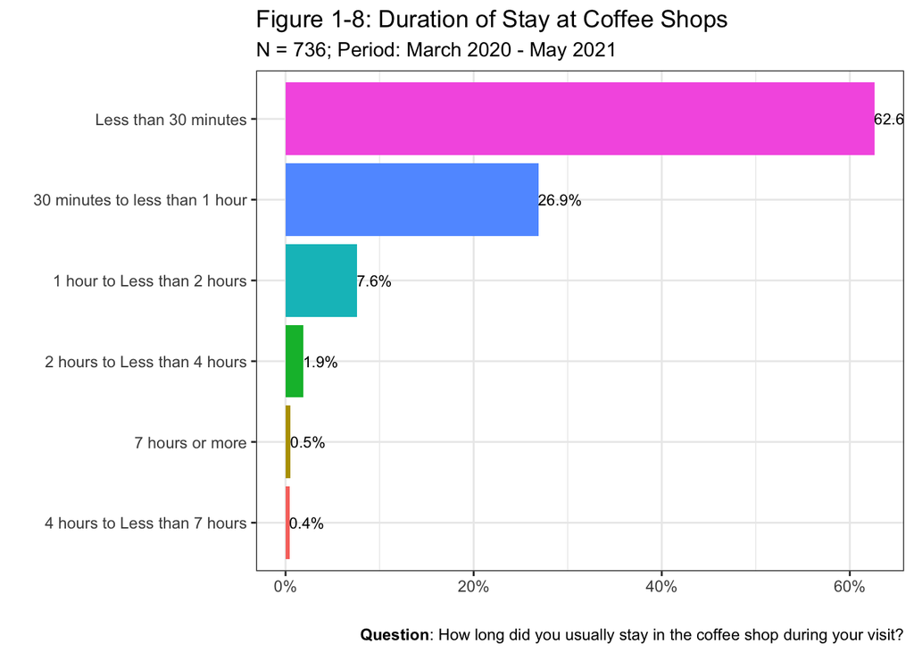

Figure 4: Duration of Stay at the Coffee Shops

```r
data |>
    select(duration) |>
    filter(!is.na(duration)) |>
    mutate(duration = haven::as_factor(duration)) |>
    count(duration) |>
    mutate(percent = n/sum(n)) |>
    mutate(duration = fct_reorder(duration, n)) |>
    ggplot(aes(duration, percent, fill = duration)) +
    geom_col(show.legend = FALSE) +
    coord_flip() +
    scale_y_continuous(labels = scales::percent) +
    geom_text(aes(label = paste0(round(percent*100, 1),"%")),
              hjust = 0.01, size = 3) +
    labs(x = "", y = "",
         title = "Figure 1-8: Duration of Stay at Coffee Shops",
         subtitle = glue("N = {N}; Period: March 2020 - May 2021"),
         caption = "**Question**: How long did you usually stay in the coffee shop during your visit?"
    ) +
    theme(plot.caption = element_markdown())
```

*Descrption: Most consumers reported staying at coffee shops for brief to moderate periods, suggesting that while visits resumed, they were cautious and potentially avoided long exposure.*

## 3.8 Type of Coffee Shops Visited

```r
cs_types <- data |>
    select(coffeeshop_type_1, coffeeshop_type_4) |>
    mutate(across(where(is.labelled), ~ replace_na(.x, 0))) |>
    mutate(across(where(is.labelled), as.numeric))

cs_types_longer <- cs_types |>
    pivot_longer(everything(), names_to = "names", values_to = "metric")

cs_type_labels <- c("Local coffee shop", "National chain coffee shop")

cs_types_longer <- cs_types_longer |>
    mutate(names = case_when(
        names == "coffeeshop_type_1" ~ "Local coffee shop",
        names == "coffeeshop_type_4" ~ "National chain coffee shop"
    )) |>
    mutate(names = fct_relevel(names, cs_type_labels))
```

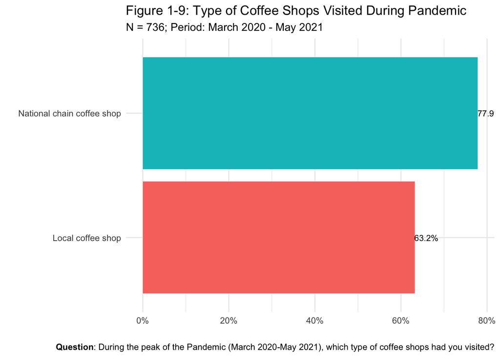

Figure 5: Type of Coffee Shops

```r
theme_set(theme_minimal())

cs_types_longer |>
    filter(!is.na(metric)) |>
    group_by(names) |>
    summarise(percent = mean(metric)) |>
    ggplot(aes(names, percent, fill = names)) +
    geom_col(show.legend = FALSE) +
    coord_flip() +
    scale_y_continuous(labels = scales::percent) +
    geom_text(aes(label = paste0(round(percent*100, 1),"%")),
              hjust = 0.01, size = 3) +
    labs(x = "", y = "",
         title = "Figure 1-9: Type of Coffee Shops Visited During Pandemic",
         subtitle = glue("N = {N}; Period: March 2020 - May 2021"),
         caption = "**Question**: During the peak of the Pandemic (March 2020-May 2021), which type of coffee shops had you visited?"
    ) +
    theme(plot.caption = element_markdown())
```

*Descrption: Consumers showed a clear preference for either local or national coffee shop chains during the pandemic. The data reveal loyalty to familiar or convenient brands during uncertain times.*

## 3.9 Preventive Behaviors Engaged During Pandemic

```r
cs_prev_bvr <- data |>
    select(prevt_behavior_1:prevt_behavior_8) |>
    mutate(across(where(is.labelled), haven::as_factor))

cs_prev_bvr_longer <- cs_prev_bvr |>
    pivot_longer(everything(), names_to = "names", values_to = "metric")

# Renaming
cs_prev_bvr_labels <- c(
    "Wore a mask when not eating/drinking",
    "Washed my hands or used hand sanitizer often",
    "Selected locations that practiced social distancing",
    "Chose coffee shops following preventative measures",
    "Urged my friends to select a coffee shop that used PM",
    "Willing to obey preventative measures",
    "Made every attempt to keep personal hygiene",
    "Learned about COVID-19 preventative measures"
)

cs_prev_bvr_longer <- cs_prev_bvr_longer |>
    mutate(names = recode(names,
        "prevt_behavior_1" = "Wore a mask when not eating/drinking",
        "prevt_behavior_2" = "Washed my hands or used hand sanitizer often",
        "prevt_behavior_3" = "Selected locations that practiced social distancing",
        "prevt_behavior_4" = "Chose coffee shops following preventative measures",
        "prevt_behavior_5" = "Urged my friends to select a coffee shop that used PM",
        "prevt_behavior_6" = "Willing to obey preventative measures",
        "prevt_behavior_7" = "Made every attempt to keep personal hygiene",
        "prevt_behavior_8" = "Learned about COVID-19 preventative measures"
    )) |>
    mutate(names = fct_relevel(names, cs_prev_bvr_labels))
```

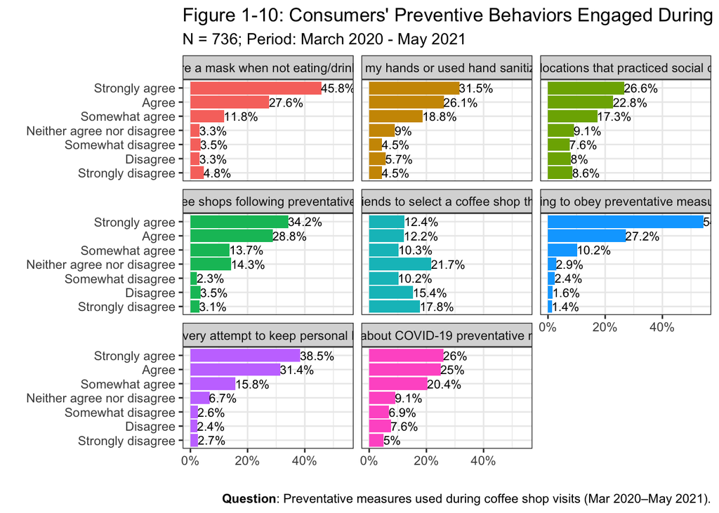

Figure 6: Preventive Behaviors Engaged

```r
theme_set(theme_bw())

cs_prev_bvr_longer |>
    filter(!is.na(metric)) |>
    group_by(names) |>
    count(metric) |>
    mutate(percent = n/sum(n)) |>
    ggplot(aes(metric, percent, fill = names)) +
    geom_col(show.legend = FALSE) +
    coord_flip() +
    facet_wrap(~ names) +
    scale_y_continuous(labels = scales::percent) +
    geom_text(aes(label = paste0(round(percent*100, 1),"%")),
              hjust = 0.01, size = 3) +
    labs(x = "", y = "",
         title = "Figure 1-10: Consumers' Preventive Behaviors Engaged During Pandemic",
         subtitle = glue("N = {N}; Period: March 2020 - May 2021"),
         caption = "**Question**: Preventative measures used during coffee shop visits (Mar 2020–May 2021)."
    ) +
    theme(plot.caption = element_markdown())
```

*Descrption: This chart illustrates the frequency of health-conscious behaviors inside coffee shops. Most consumers reported wearing masks, sanitizing, and choosing shops with visible safety protocols, indicating a strong sense of personal responsibility.*

## 3.10 Mask-Wearing Behaviors at the Coffee Shop During Pandemic

```r
cs_mw_behvr <- data |>
    select(past_behvr1_1, past_behvr2_1) |>
    mutate(across(where(is.labelled), haven::as_factor))

cs_mw_behvr <- cs_mw_behvr |>
    mutate(past_behvr1_1 = recode(past_behvr1_1, "1" = "1(Never)", "7" = "7(Always)"),
           past_behvr2_1 = recode(past_behvr2_1, "1" = "1(False)", "7" = "7(True)"))

cs_mw_behvr_longer <- cs_mw_behvr |>
    pivot_longer(everything(), names_to = "names", values_to = "metric")

cs_mw_behvr_labels <- c(
    "Frequency of wearing a mask during my stay",
    "Wore a mask whenever staying at a Coffee Shop"
)

cs_mw_behvr_longer <- cs_mw_behvr_longer |>
    mutate(names = case_when(
        names == "past_behvr1_1" ~ "Frequency of wearing a mask during my stay",
        names == "past_behvr2_1" ~ "Wore a mask whenever staying at a Coffee Shop"
    )) |>
    mutate(names = fct_relevel(names, cs_mw_behvr_labels))
```

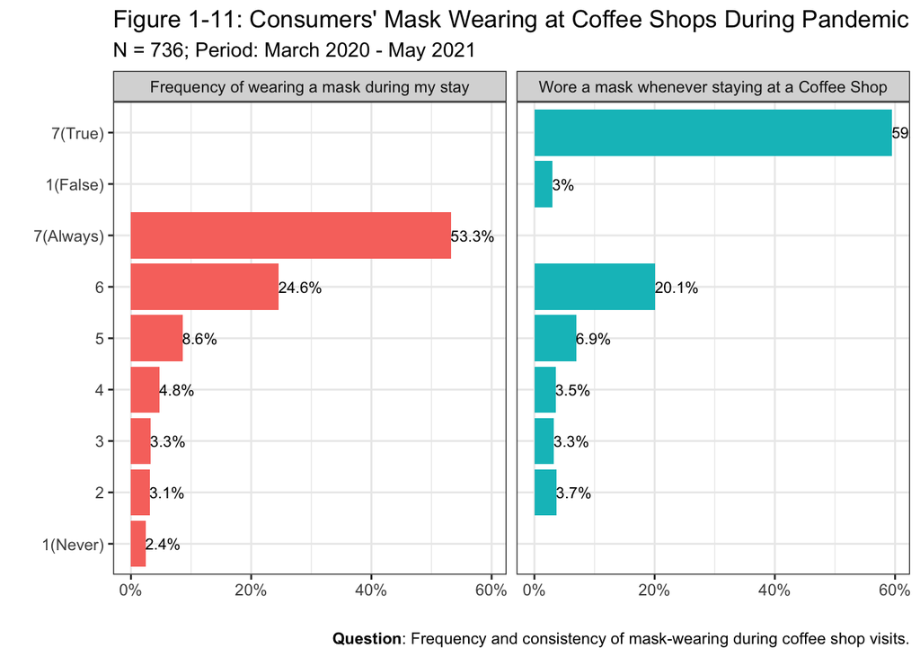

Figure 7: Mask Wearing Behaviors at the Coffee Shop During Pandemic

```r
theme_set(theme_bw())

cs_mw_behvr_longer |>
    filter(!is.na(metric)) |>
    group_by(names) |>
    count(metric) |>
    mutate(percent = n/sum(n)) |>
    ggplot(aes(metric, percent, fill = names)) +
    geom_col(show.legend = FALSE) +
    coord_flip() +
    facet_wrap(~ names) +
    scale_y_continuous(labels = scales::percent) +
    geom_text(aes(label = paste0(round(percent*100, 1),"%")),
              hjust = 0.01, size = 3) +
    labs(x = "", y = "",
         title = "Figure 1-11: Consumers' Mask Wearing at Coffee Shops During Pandemic",
         subtitle = glue("N = {N}; Period: March 2020 - May 2021"),
         caption = "**Question**: Frequency and consistency of mask-wearing during coffee shop visits."
    ) +
    theme(plot.caption = element_markdown())
```

*Descrption: A majority of respondents consistently wore masks while visiting coffee shops. This supports the idea that mask-wearing had become normalized behavior during this time.*